# The cost of admission

Magic Kingdom Ticket Prices 1971-2018

Chris Hamm

2019-07-16

# Introduction

Trips to Walt Disney World are expensive and becoming more so all the time. It seems that every few months we hear about another hike in ticket prices and March of 2019 was no exception. With the announcment that Star Wars Galaxy’s Edge is opening in August 2019 at Walt Disney World there was an associated hike in [ticket prices](https://www.orlandosentinel.com/business/tourism/os-cfb-disney-ticket-prices-20190313-story.html). Add this to the news that [variable pricing](http://time.com/money/5405838/disney-world-ticket-prices-2018/) was introduced in October 2018. Ever-increasing ticket prices can make it feel like Disney is pricing out the middle-class.

With all the recent price increases, I wanted to take a look at the history of the cost of a single day admission to the Magic Kingdom and ask a few questions:

1. Adjusted for inflation, does it cost more to visit Walt Disney World’s Magic Kingdom today than it did in 1971?
2. What will the next price increase be?

### TL;DR

# Data

To ask these questions I needed data. I needed data on: the historic price of admission to the Magic Kingdom; the dates those ticket prices were in effect; and the Disney CEO at the time. It wasn’t hard to find websites with the history of admission prices. Whenever possible, I selected the most expensive ticket available that was not a park-hopper. I used the data from this [site](http://allears.net/walt-disney-world/wdw-planning/wdw-ticket-increase-guide/) and cross referenced it [here](https://www.travelandleisure.com/trip-ideas/disney-vacations/disney-world-ticket-costs-over-time). I got the dates for the Disney CEOs from the book [Disney War](https://en.wikipedia.org/wiki/DisneyWar) by James B. Stewart and cross referenced them with this [Wikipedia article](https://en.wikipedia.org/wiki/List_of_management_of_The_Walt_Disney_Company). Please let me know if I inadvertently included the incorrect data in this post, and please point me to your source so I can update the post.

Because this is a data science blog post, I’ve posted the code to a [repository](https://github.com/butterflyology/Theme_Park_prices) so that anyone with a computer and the desire can recreate the analyses presented here.

Let’s take a look at the data set I created. There are three columns in the data set:

1. `Date` - The date the admission price was in effect.
2. `Price` - The cost of single-day admission to the Magic Kingdom
3. `CEO` - The Disney CEO at the time of the price.

| Date | Price (USD) | CEO |
| --- | --- | --- |
| 1971-10-01 | 3.50 | Disney |
| 1972-02-01 | 3.75 | Tatum |
| 1973-04-01 | 4.50 | Tatum |
| 1974-06-01 | 5.25 | Tatum |
| 1975-12-01 | 6.00 | Tatum |
| 1978-06-01 | 6.50 | Walker |
| 1979-04-01 | 7.00 | Walker |
| 1980-03-01 | 7.50 | Walker |
| 1980-11-01 | 8.00 | Walker |
| 1981-10-01 | 9.50 | Walker |
| 1982-06-01 | 13.25 | Walker |
| 1982-09-01 | 15.00 | Walker |
| 1983-10-01 | 17.00 | Miller |
| 1984-06-01 | 18.00 | Miller |
| 1985-06-01 | 19.50 | Eisner |
| 1985-11-01 | 21.50 | Eisner |
| 1986-03-01 | 23.00 | Eisner |
| 1986-06-01 | 24.50 | Eisner |
| 1986-12-01 | 26.00 | Eisner |
| 1987-12-01 | 28.00 | Eisner |
| 1989-05-01 | 29.00 | Eisner |
| 1990-02-01 | 31.00 | Eisner |
| 1991-02-01 | 33.00 | Eisner |
| 1992-06-01 | 34.00 | Eisner |
| 1993-05-01 | 35.00 | Eisner |
| 1994-03-01 | 36.00 | Eisner |
| 1995-02-01 | 37.00 | Eisner |
| 1996-02-01 | 38.50 | Eisner |
| 1997-03-01 | 39.75 | Eisner |
| 1998-04-01 | 42.00 | Eisner |
| 1999-05-01 | 44.00 | Eisner |
| 2000-01-01 | 46.00 | Eisner |
| 2001-01-01 | 48.00 | Eisner |
| 2002-09-01 | 50.00 | Eisner |
| 2003-06-01 | 52.00 | Eisner |
| 2004-03-01 | 54.75 | Eisner |
| 2005-01-01 | 59.75 | Eisner |
| 2006-01-01 | 63.00 | Iger |
| 2006-08-01 | 67.00 | Iger |
| 2007-08-01 | 71.00 | Iger |
| 2008-08-01 | 75.00 | Iger |
| 2009-08-01 | 79.00 | Iger |
| 2010-08-01 | 82.00 | Iger |
| 2011-06-01 | 85.00 | Iger |
| 2012-06-01 | 89.00 | Iger |
| 2013-06-01 | 95.00 | Iger |
| 2014-02-01 | 99.00 | Iger |
| 2015-02-01 | 105.00 | Iger |
| 2016-02-01 | 110.00 | Iger |
| 2018-02-01 | 122.00 | Iger |
| 2018-10-16 | 129.00 | Iger |
| 2019-03-13 | 139.00 | Iger |

# Visuals

You always want to look at the data. Here’s a plot of admission price by date on the horizontal (x-axis) and the cost of admission to the Magic Kingdom on the vertical axis (y-axis) in US Dollars. Each point’s color represents the Disney CEO at the time the price increased.

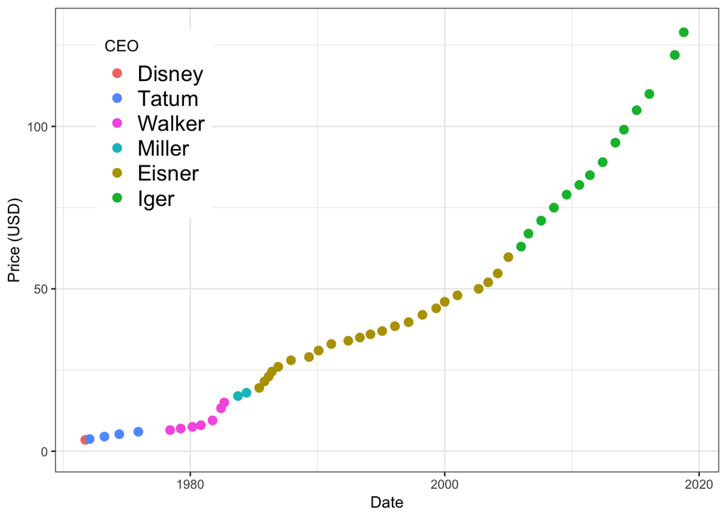

Does it look like Mr. Iger has upped the rate of admission increases faster than the other CEOs? Maybe. But this isn’t an apples-to-apples comparison. We need to adjust the prices for inflation. We will adjust inflation using the “Consumer Price Index for All Urban Consumers: All Items” from the rock stars over at the Bureau of Labor Statistics.

We’ve added three new columns to out data set:

1. `Year` - We used this column to calculate the CPI
2. `Adjustment` - The adjusted CPI value
3. `Adjusted Price` - The original `Price` of a ticket times the `Adjustment`.

| Date | Price (USD) | CEO | Year | Adjustment | Adjusted Price (USD) |
| --- | --- | --- | --- | --- | --- |
| 1971-10-01 | 3.50 | Disney | 1971 | 6.279753 | 21.97914 |
| 1972-02-01 | 3.75 | Tatum | 1972 | 6.080734 | 22.80275 |
| 1973-04-01 | 4.50 | Tatum | 1973 | 5.722574 | 25.75158 |
| 1974-06-01 | 5.25 | Tatum | 1974 | 5.154958 | 27.06353 |
| 1975-12-01 | 6.00 | Tatum | 1975 | 4.723183 | 28.33910 |
| 1978-06-01 | 6.50 | Walker | 1978 | 3.896671 | 25.32836 |
| 1979-04-01 | 7.00 | Walker | 1979 | 3.502530 | 24.51771 |
| 1980-03-01 | 7.50 | Walker | 1980 | 3.085883 | 23.14412 |
| 1980-11-01 | 8.00 | Walker | 1980 | 3.085883 | 24.68706 |
| 1981-10-01 | 9.50 | Walker | 1981 | 2.795733 | 26.55946 |
| 1982-06-01 | 13.25 | Walker | 1982 | 2.633550 | 34.89453 |
| 1982-09-01 | 15.00 | Walker | 1982 | 2.633550 | 39.50325 |
| 1983-10-01 | 17.00 | Miller | 1983 | 2.552890 | 43.39914 |
| 1984-06-01 | 18.00 | Miller | 1984 | 2.446042 | 44.02876 |
| 1985-06-01 | 19.50 | Eisner | 1985 | 2.362689 | 46.07243 |
| 1985-11-01 | 21.50 | Eisner | 1985 | 2.362689 | 50.79781 |
| 1986-03-01 | 23.00 | Eisner | 1986 | 2.317636 | 53.30562 |
| 1986-06-01 | 24.50 | Eisner | 1986 | 2.317636 | 56.78208 |
| 1986-12-01 | 26.00 | Eisner | 1986 | 2.317636 | 60.25853 |
| 1987-12-01 | 28.00 | Eisner | 1987 | 2.237571 | 62.65198 |
| 1989-05-01 | 29.00 | Eisner | 1989 | 2.051169 | 59.48391 |
| 1990-02-01 | 31.00 | Eisner | 1990 | 1.945726 | 60.31751 |
| 1991-02-01 | 33.00 | Eisner | 1991 | 1.867016 | 61.61153 |
| 1992-06-01 | 34.00 | Eisner | 1992 | 1.811905 | 61.60476 |
| 1993-05-01 | 35.00 | Eisner | 1993 | 1.759649 | 61.58773 |
| 1994-03-01 | 36.00 | Eisner | 1994 | 1.715131 | 61.74473 |
| 1995-02-01 | 37.00 | Eisner | 1995 | 1.668328 | 61.72812 |
| 1996-02-01 | 38.50 | Eisner | 1996 | 1.620732 | 62.39819 |
| 1997-03-01 | 39.75 | Eisner | 1997 | 1.583712 | 62.95254 |
| 1998-04-01 | 42.00 | Eisner | 1998 | 1.559585 | 65.50257 |
| 1999-05-01 | 44.00 | Eisner | 1999 | 1.526115 | 67.14906 |
| 2000-01-01 | 46.00 | Eisner | 2000 | 1.476409 | 67.91482 |
| 2001-01-01 | 48.00 | Eisner | 2001 | 1.435963 | 68.92624 |
| 2002-09-01 | 50.00 | Eisner | 2002 | 1.413410 | 70.67050 |
| 2003-06-01 | 52.00 | Eisner | 2003 | 1.381659 | 71.84629 |
| 2004-03-01 | 54.75 | Eisner | 2004 | 1.345760 | 73.68038 |
| 2005-01-01 | 59.75 | Eisner | 2005 | 1.301939 | 77.79087 |
| 2006-01-01 | 63.00 | Iger | 2006 | 1.261299 | 79.46184 |
| 2006-08-01 | 67.00 | Iger | 2006 | 1.261299 | 84.50704 |
| 2007-08-01 | 71.00 | Iger | 2007 | 1.226103 | 87.05332 |
| 2008-08-01 | 75.00 | Iger | 2008 | 1.181047 | 88.57851 |
| 2009-08-01 | 79.00 | Iger | 2009 | 1.184843 | 93.60256 |
| 2010-08-01 | 82.00 | Iger | 2010 | 1.165764 | 95.59264 |
| 2011-06-01 | 85.00 | Iger | 2011 | 1.130277 | 96.07356 |
| 2012-06-01 | 89.00 | Iger | 2012 | 1.107320 | 98.55151 |
| 2013-06-01 | 95.00 | Iger | 2013 | 1.091322 | 103.67558 |
| 2014-02-01 | 99.00 | Iger | 2014 | 1.073972 | 106.32325 |
| 2015-02-01 | 105.00 | Iger | 2015 | 1.072690 | 112.63251 |
| 2016-02-01 | 110.00 | Iger | 2016 | 1.059238 | 116.51618 |
| 2018-02-01 | 122.00 | Iger | 2018 | 1.012430 | 123.51643 |
| 2018-10-16 | 129.00 | Iger | 2018 | 1.012430 | 130.60344 |
| 2019-03-13 | 139.00 | Iger | 2019 | 1.000000 | 139.00000 |

Now we have our admission prices adjusted for inflation. Let’s plot:

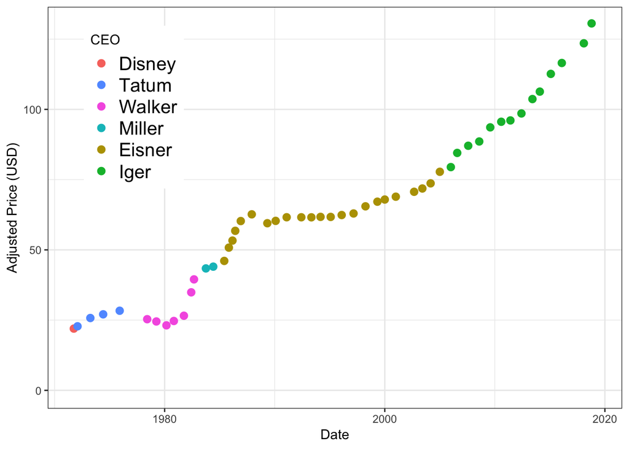

It’s helpful to see the adjusted prices side by side with the original prices.

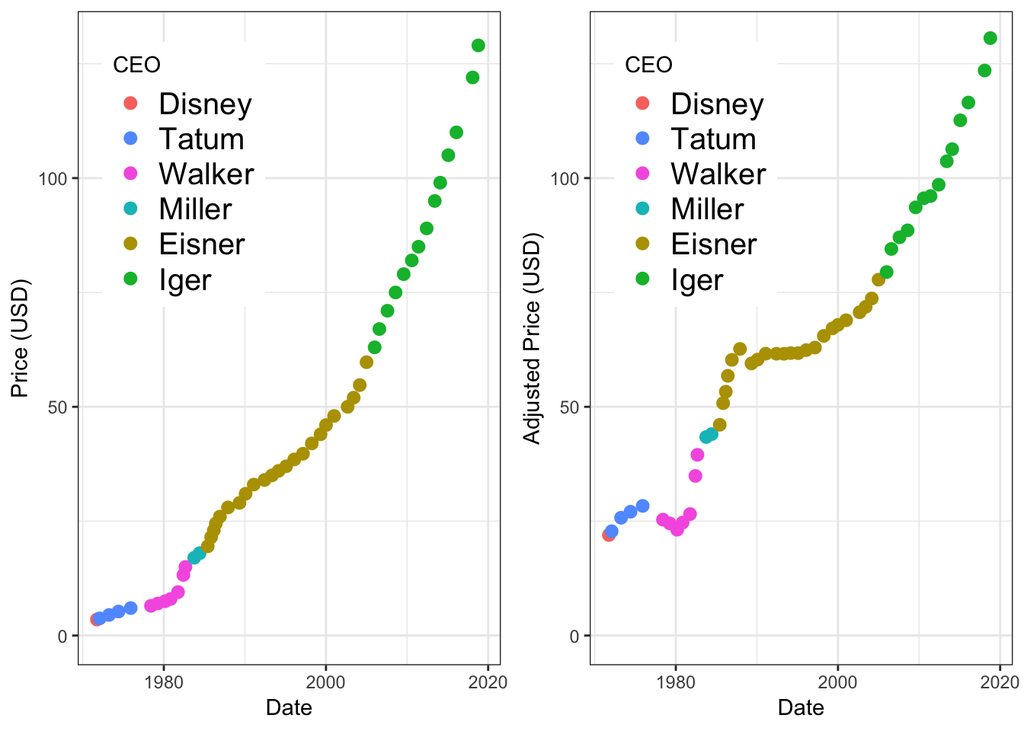

What kind of blows my mind is that the Magic Kingdom’s prices have, on occasion, not kept up with inflation. When I saw this I manually checked the adjustments I calculated using the Bureau of Labor Statistics own [calculator](https://data.bls.gov/cgi-bin/cpicalc.pl). My calculations were within $0.20 each time.

On to the questions.

# Eisner vs. Iger

1. Are ticket prices rising faster now?

Let’s look at the rate of increase for each CEO. We will fit a straight line through each CEOs prices and use that line to describe each pricing regime. We will use the same plot as before and overlay lines on to it. Roy O. Disney was CEO for only one price point and won’t get a line.

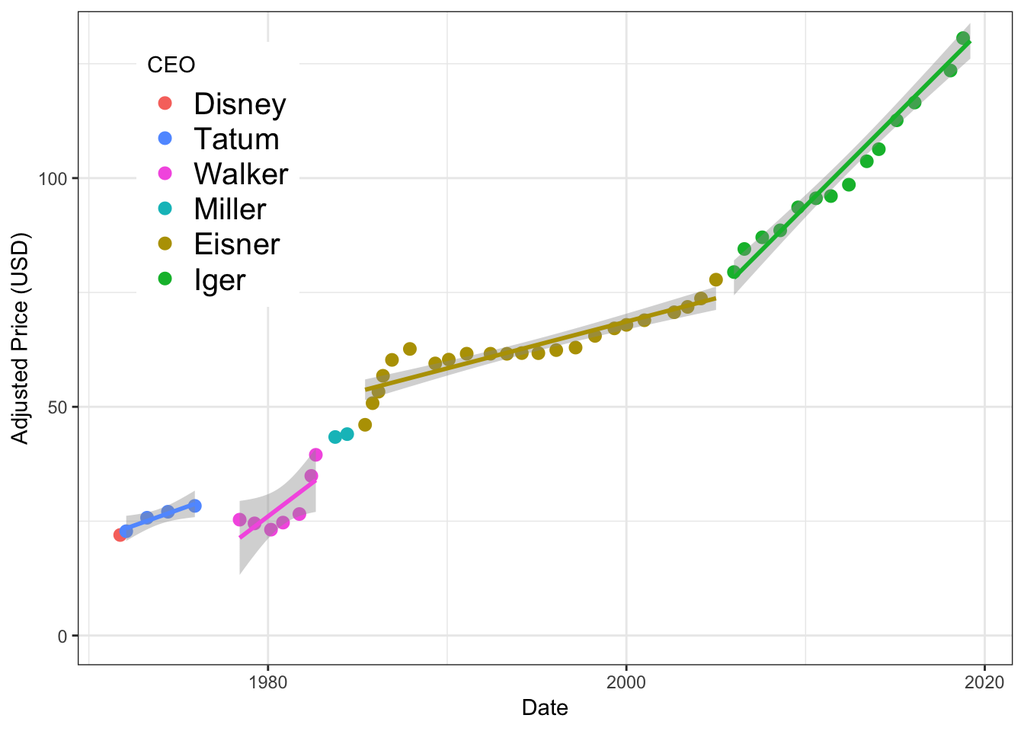

The shaded regions around the lines represent the confidence interval around the line. A confidence interval is how sure we are of our estimate of the line, and narrow intervals are better.

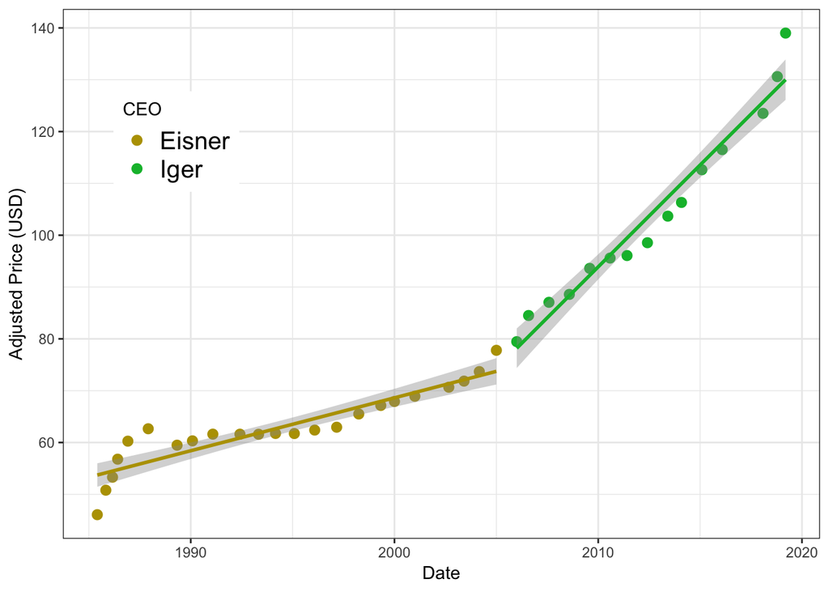

# Tracking inflation

Adjusted for inflation, does it cost more to visit Disney today than it did in 1971?

Let’s add to our previous plot.

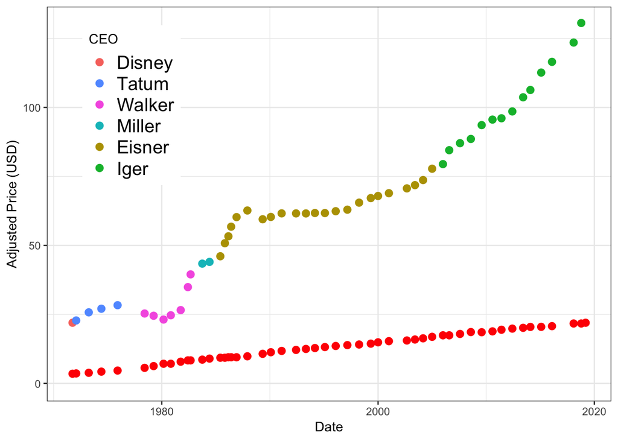

The line of red dots along the bottom of the plot represents the cost of admission to the Magic Kingdom if the cost had just tracked inflation.

# The next price increase

Len Testa and others have noted that the current pricing scheme does not contain information for December, 2019. This date corresponds to the approximate opening of Star Wars Galaxy’s Edge at Walt Disney World. Using our model to predict out to December, 2019 we estimate the cost of admission will be ~$130 for a one day ticket. This may be a low estimate because themed entertainment hasn’t seen anything like Galaxy’s Edge. Disney could pretty much set any price and fans will pay it. Let’s plot this out.

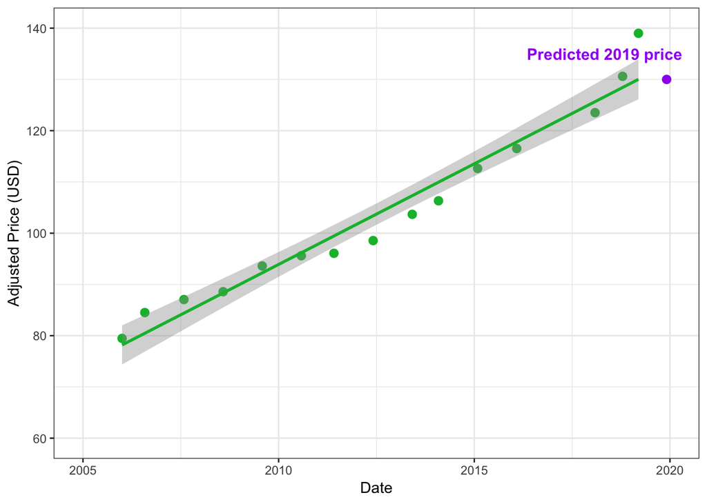

I think this prediction is low because it doesn’t take into account the opening of Star Wars Galaxy’s Edge.